# Species discrimination and prediction

Tomasz Włodarczyk

25-11-2023

# Species markers

This report shows how the peaks discriminative for *F. sanguinea* and *F. fusca* were determined. We will use the chemical data collected from the filed colonies in the [earlier study](https://www.sciencedirect.com/science/article/abs/pii/S0022191016301640). In this way our method of marker selection is blind to the dataset to which markers will be applied avoiding potential source of the bias in the analysis results.

```r
suppressMessages({
  library(sangchem)
  library(stringi)
  library(dplyr)
  library(mixOmics)
})

# load data from the the earlier study
data("field_colonies")

# select samples from F. sanguinea ants and free-living F. fusca ants encoded in chromatogram_ID
fusca_samples <- as.character(unique(field_colonies$chromatogram_ID)[stri_detect_regex(unique(field_colonies$chromatogram_ID), "fus[0-9].?-[0-9]\\([1-2]\\)")])
sanguinea_samples<-as.character(unique(field_colonies$chromatogram_ID)[stri_detect_regex(unique(field_colonies$chromatogram_ID),"sangFs[0-9].?\\([0-9]\\)")])

# remove outliers
sanguinea_samples <- setdiff(sanguinea_samples,c("sangFs2(1)","sangFs5(2)","sangFs26(1)","sangFs26(2)"))
fusca_samples <- setdiff(fusca_samples,c("fus9-2(1)", "fus26-3(2)"))
discrimination_data <- filter(field_colonies,chromatogram_ID %in% c(fusca_samples,sanguinea_samples))
peak_prop_unfiltered <- peak_proportions_table(discrimination_data)
# feature selection
peak_prop <- freq_abun_QC(peak_prop_unfiltered)
# re-normalize rows to 1
peak_prop <- peak_prop/rowSums(peak_prop)
# replace zeros with a small number before transformation
peak_prop[peak_prop==0] <- 10^-16
# apply central log ratio transformation
peak_transformed <- t(apply(peak_prop, 1, clr_transformation))
```

```r
PCA_species_discr <- prcomp(peak_transformed, scale. = TRUE)
```

We also need to deifne our reponse variable to be explained by discrimination model.

```r
#define groups to be compared
Y <- rownames(PCA_species_discr$x) %in% sanguinea_samples
```

Now that we have prepared the input data we can run the model. The following workflow is based on the tutorial available at the official [`mixOmics` package web site](https://mixomics.org/mixmc/hmp-bodysites-case-study/).

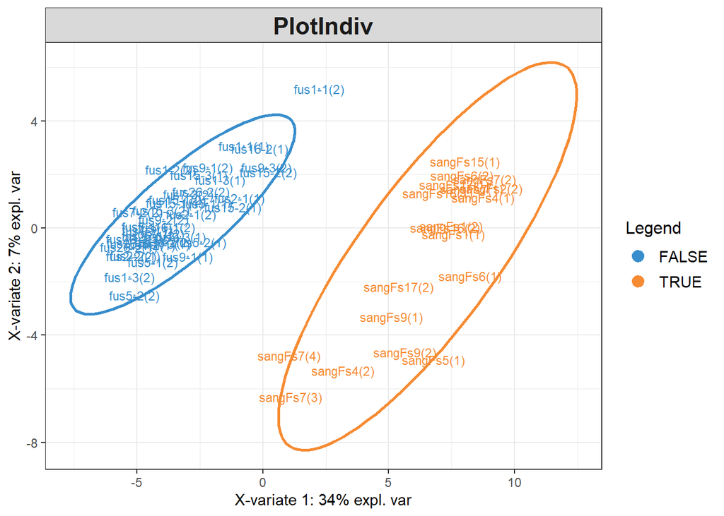

```r
# run the main model
species_discrimination_PC.plsda <- plsda(PCA_species_discr$x, Y, ncomp=10, scale=FALSE)
plotIndiv(species_discrimination_PC.plsda,group=Y,
          legend=TRUE,ellipse=TRUE,comp=1:2)
```

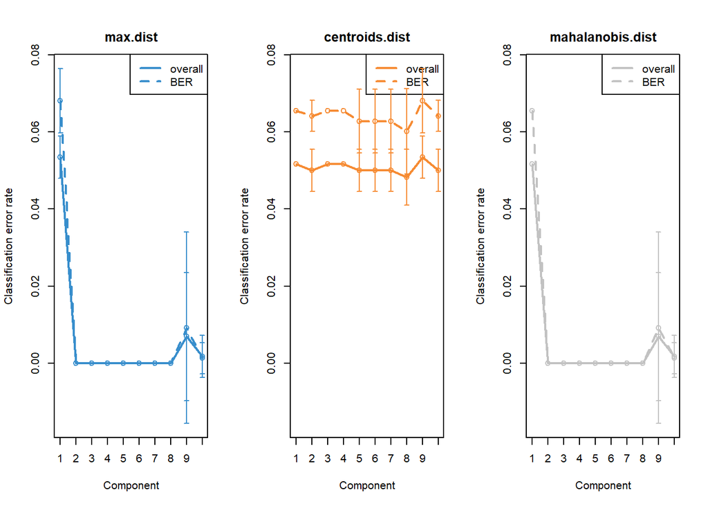

```r
# determine the optimal number of components used in the model
spec_discr_PC.plsda.perf<-perf(species_discrimination_PC.plsda, nrepeat = 10,folds=5,
                            progressBar = FALSE,validation = "Mfold",
                            auc=TRUE, scale=FALSE)

plot(spec_discr_PC.plsda.perf, sd = TRUE, overlay = 'measure')
```

The diagnstic plots suggests that we should keep 2 components for the final model.

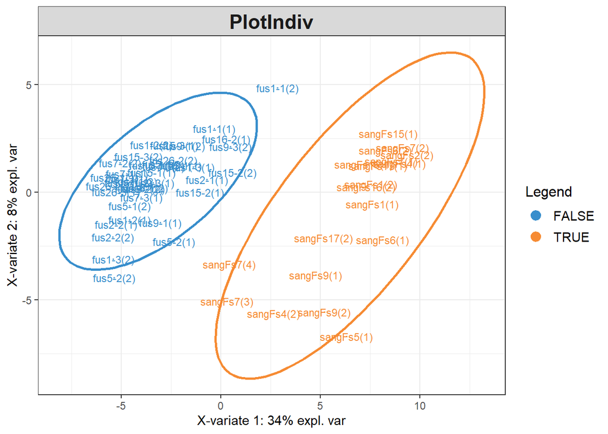

```r
selected_n <- 2

# dtermine the number of the original variables to be kept in each component (actually
# here we have only one component)
spec_discr_PC.splsda <- tune.splsda(PCA_species_discr$x,Y,test.keepX = c(1:60),ncomp = selected_n,
                                 validation="Mfold", progressBar=FALSE, dist="max.dist",
                                 nrepeat=5, cpus=2, folds=5, measure="BER", scale=FALSE)

# final model
species_prediction_model <- splsda(PCA_species_discr$x, Y, ncomp=selected_n,
                           keepX =spec_discr_PC.splsda$choice.keepX, scale=FALSE)

# visuzalize results for the first two commponents
plotIndiv(species_prediction_model, group=Y, legend=TRUE, ellipse=TRUE, comp=1:2)
```

Now we want to correlate relative abundances of CHCs with the species predicted by the model for each sample.

```r
# quantify predicted species (F. sanguinea closer to one and F. fusca closer to 0)
predicted_species <- predict(species_prediction_model, PCA_species_discr$x)$predict[,2,species_prediction_model$ncomp]

library(Hmisc)
cor_p_val<-rcorr(cbind(peak_prop, predicted_species))
cor_p_val$P[cor_p_val$r==1]<-0
#significance threshold = 0.05
significant_correlations <- cor_p_val$r["predicted_species",][cor_p_val$P["predicted_species",]<0.05]
peaks_sang <- names(significant_correlations)[significant_correlations>0]
peaks_sang <- as.numeric((setdiff(peaks_sang,"predicted_species")))
peaks_fusca <- as.numeric(names(significant_correlations)[significant_correlations<0])
print(peaks_sang)
```

```
##  [1]  22  24  30  35  42  43  47  49  51  56  57  58  59  61  63  68  71  75  76  77  78  79  81  83  85  92  93  94  95  97
## [31]  99 102 109 110 111 113 124 125 126
```

```r
print(peaks_fusca)
```

```
##  [1]  7  8  9 11 12 14 15 16 18 19 23 27 29 31 32 33 36 37 38 41 45 46 55
```

The objects `peaks_sang`, `peaks_fusca`, `species_prediction_model` and `PCA_species_discr` are stored in the package and can be collectively loaded into the global environment along with the other objects by running `load_globals()`.

## Peak position on the species discriminant axis

We might ask how a given peak compares to other in term of being characteristic more of one or the other species. Correspondingly we will generate the artificial profiles which are composed of only one peak to see how each peak contributes to the species prediction.

```r
unit_input <- diag(rep(1, ncol(peak_prop)))
colnames(unit_input) <- rownames(unit_input) <-colnames(peak_prop)
res <- calculate_SII(unit_input)
colnames(res)[1] <- "peak ID"
# normalize scores
res[,2] <- res[,2] - mean(res[,2])
res[,2] <- res[,2]/sd(res[,2])
print(res[order(res$predicted_species),])
```

```
##     peak ID predicted_species
## 15       15       -1.67522648
## 33       33       -1.59626551
## 23       23       -1.54303837
## 8         8       -1.47463684
## 29       29       -1.46619152
## 12       12       -1.44049558
## 16       16       -1.43112785
## 37       37       -1.37360481
## 18       18       -1.37262224
## 14       14       -1.34644266
## 32       32       -1.34389491
## 31       31       -1.30661216
## 7         7       -1.27324585
## 38       38       -1.17702799
```

[output cut: 62 more lines]

# Species identity score

Ants in mixed colonies mixed CHCs to produce hybrid chemical identity. Here we develop the method to assign each sample a number indicating how much it is characteristic of one or the other species. The main idea is to fit a sPLS_DA model to the training set (sampled from field colonies) and use it predict the explanatory variable (species) in the test data (samples from experimental colonies). However the sPLS_DA model run on the raw data will yield the classificator which used only few variables (peaks) due to the well separation of samples of both species. The unused variables might also be informative in the species discrimination task. We want to use as much data as it is possible to make robust predictions and thus we will use principal component analysis output. Thus, the rotation matrix from the principal component analysis will be used to transform input data to the discrimination model. The correspondig code in encapsulated in the `claculate_SII` function.

## Data preparation

```r
data("development_data")
dev_samples <- filter(development_data, caste=="worker",!is.na(head_width), !remarks %in% c("aggression actor", "aggression target", "queenless colony")) %>%
  dplyr::select(chromatogram_ID, species, colony, sang_prop, callow, census_date)
normalized_abundances <- peak_proportions_table(mass_spectra_data[mass_spectra_data$chromatogram_ID %in% dev_samples$chromatogram_ID,])
species_indices <- calculate_SII(normalized_abundances)
dev_samples <- left_join(dev_samples, species_indices)
```

## Predicted species of different categories of ants as a function of the proportion of *F. sanguinea* ants in a colony

### Mature *F. sanguinea*

```r
library(lmerTest)
library(DHARMa)
model_input <- dev_samples[dev_samples$species=="F. sanguinea"&dev_samples$callow==0,]
lm_model <- lmer(predicted_species~sang_prop+(1|colony)+(1|colony:census_date), data=model_input)
```

```
## boundary (singular) fit: see help('isSingular')
```

```r
print(summary(lm_model))
```

```
## Linear mixed model fit by REML. t-tests use Satterthwaite's method ['lmerModLmerTest']
## Formula: predicted_species ~ sang_prop + (1 | colony) + (1 | colony:census_date)
##    Data: model_input
##
## REML criterion at convergence: -44
##
## Scaled residuals:
##     Min      1Q  Median      3Q     Max
## -1.8160 -0.6041  0.0047  0.6844  1.2791
##
## Random effects:
##  Groups             Name        Variance Std.Dev.
##  colony:census_date (Intercept) 0.01495  0.1223
##  colony             (Intercept) 0.00000  0.0000
##  Residual                       0.01479  0.1216
## Number of obs: 65, groups:  colony:census_date, 42; colony, 16
##
## Fixed effects:
##             Estimate Std. Error       df t value Pr(>|t|)
## (Intercept)  0.30348    0.04350 38.77027   6.976 2.38e-08 ***
## sang_prop    0.72833    0.08296 38.19407   8.779 1.07e-10 ***
## ---
## Signif. codes:  0 '***' 0.001 '**' 0.01 '*' 0.05 '.' 0.1 ' ' 1
##
## Correlation of Fixed Effects:
##           (Intr)
## sang_prop -0.827
## optimizer (nloptwrap) convergence code: 0 (OK)
## boundary (singular) fit: see help('isSingular')
```

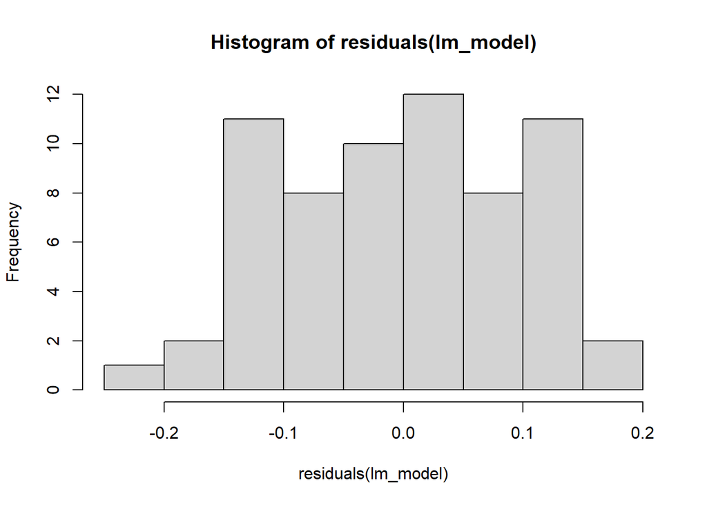

```r
# model diagnostics
hist(residuals(lm_model))
```

```r
print(shapiro.test(residuals(lm_model)))
```

```
##
##  Shapiro-Wilk normality test
##
## data:  residuals(lm_model)
## W = 0.9648, p-value = 0.06122
```

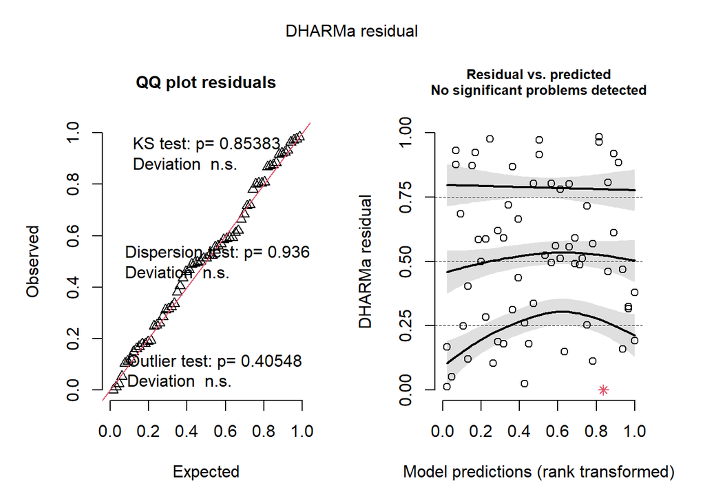

```r
simulationOutput <- simulateResiduals(fittedModel = lm_model, plot = FALSE)
plot(simulationOutput)
```

### *F. fusca*

```r
model_input <- dev_samples[dev_samples$species=="F. fusca",]
lm_model <- lmer(predicted_species~sang_prop+(1|colony)+(1|colony:census_date), data=model_input)
```

```
## boundary (singular) fit: see help('isSingular')
```

```r
print(summary(lm_model))
```

```
## Linear mixed model fit by REML. t-tests use Satterthwaite's method ['lmerModLmerTest']
## Formula: predicted_species ~ sang_prop + (1 | colony) + (1 | colony:census_date)
##    Data: model_input
##
## REML criterion at convergence: -44.2
##
## Scaled residuals:
##      Min       1Q   Median       3Q      Max
## -1.93003 -0.41989 -0.06146  0.36678  1.92050
##
## Random effects:
##  Groups             Name        Variance  Std.Dev.
##  colony:census_date (Intercept) 2.253e-02 1.501e-01
##  colony             (Intercept) 1.140e-18 1.068e-09
##  Residual                       1.308e-02 1.144e-01
## Number of obs: 78, groups:  colony:census_date, 55; colony, 20
##
## Fixed effects:
##             Estimate Std. Error       df t value Pr(>|t|)
## (Intercept)  0.18546    0.03497 49.92031   5.303 2.60e-06 ***
## sang_prop    0.72257    0.08340 48.44005   8.664 2.07e-11 ***
## ---
## Signif. codes:  0 '***' 0.001 '**' 0.01 '*' 0.05 '.' 0.1 ' ' 1
##
## Correlation of Fixed Effects:
##           (Intr)
## sang_prop -0.717
## optimizer (nloptwrap) convergence code: 0 (OK)
## boundary (singular) fit: see help('isSingular')
```

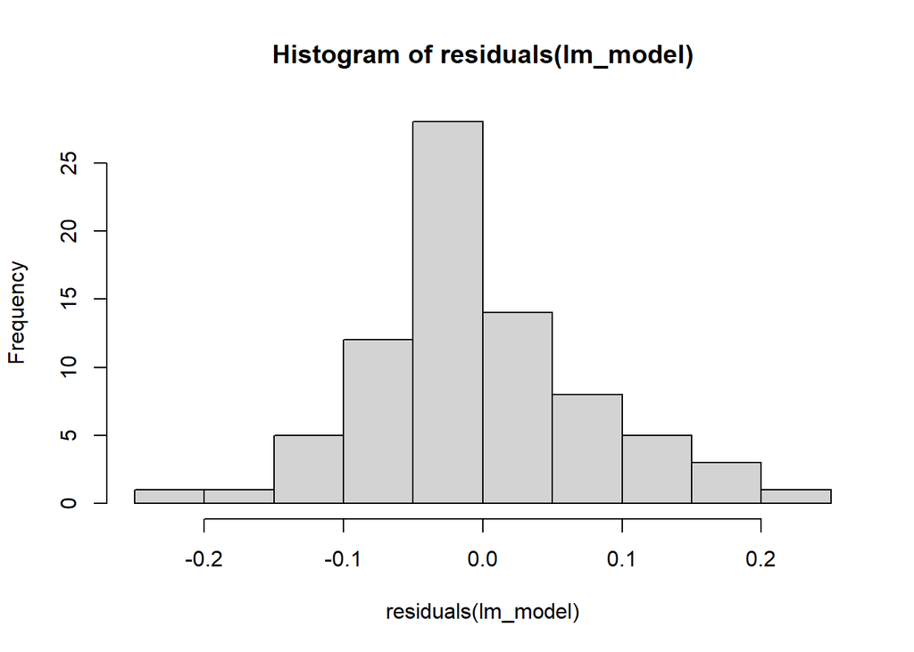

```r
# model diagnostics
hist(residuals(lm_model))
```

```r
print(shapiro.test(residuals(lm_model)))
```

```
##
##  Shapiro-Wilk normality test
##
## data:  residuals(lm_model)
## W = 0.97339, p-value = 0.1016
```

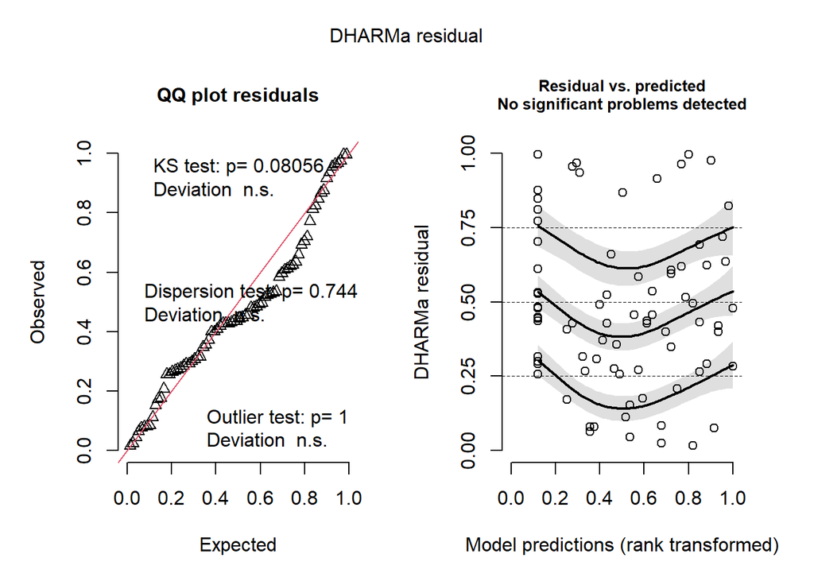

```r
simulationOutput <- simulateResiduals(fittedModel = lm_model, plot = FALSE)
plot(simulationOutput)
```

### Callow *F. sanguinea*

```r
model_input <- dev_samples[dev_samples$species=="F. sanguinea"&dev_samples$callow==1,]
lm_model <- lmer(predicted_species~sang_prop+(1|colony), data=model_input)
```

```
## boundary (singular) fit: see help('isSingular')
```

```r
print(summary(lm_model))
```

```
## Linear mixed model fit by REML. t-tests use Satterthwaite's method ['lmerModLmerTest']
## Formula: predicted_species ~ sang_prop + (1 | colony)
##    Data: model_input
##
## REML criterion at convergence: -26.1
##
## Scaled residuals:
##     Min      1Q  Median      3Q     Max
## -1.8860 -0.5397 -0.2977  0.5056  2.0693
##
## Random effects:
##  Groups   Name        Variance Std.Dev.
##  colony   (Intercept) 0.00000  0.0000
##  Residual             0.02107  0.1452
## Number of obs: 32, groups:  colony, 16
##
## Fixed effects:
##             Estimate Std. Error      df t value Pr(>|t|)
## (Intercept)   0.1386     0.0457 30.0000   3.033  0.00496 **
## sang_prop     0.7944     0.0859 30.0000   9.247 2.74e-10 ***
## ---
## Signif. codes:  0 '***' 0.001 '**' 0.01 '*' 0.05 '.' 0.1 ' ' 1
##
## Correlation of Fixed Effects:
##           (Intr)
## sang_prop -0.827
## optimizer (nloptwrap) convergence code: 0 (OK)
## boundary (singular) fit: see help('isSingular')
```

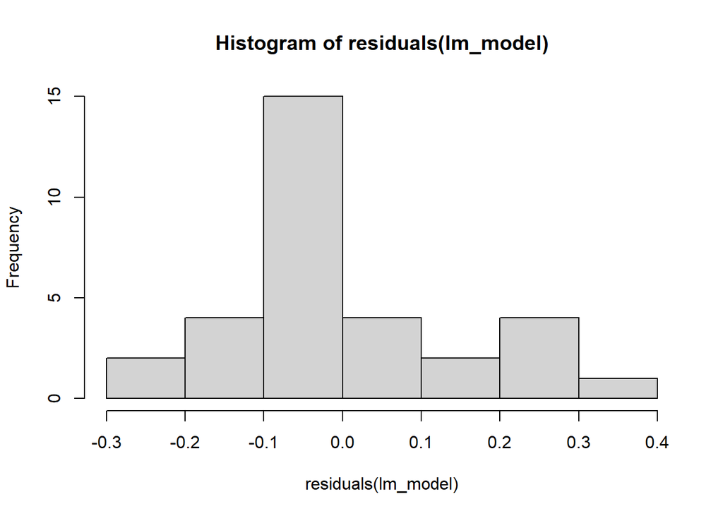

```r
# model diagnostics
hist(residuals(lm_model))
```

```r
print(shapiro.test(residuals(lm_model)))
```

```
##
##  Shapiro-Wilk normality test
##
## data:  residuals(lm_model)
## W = 0.92525, p-value = 0.02892
```

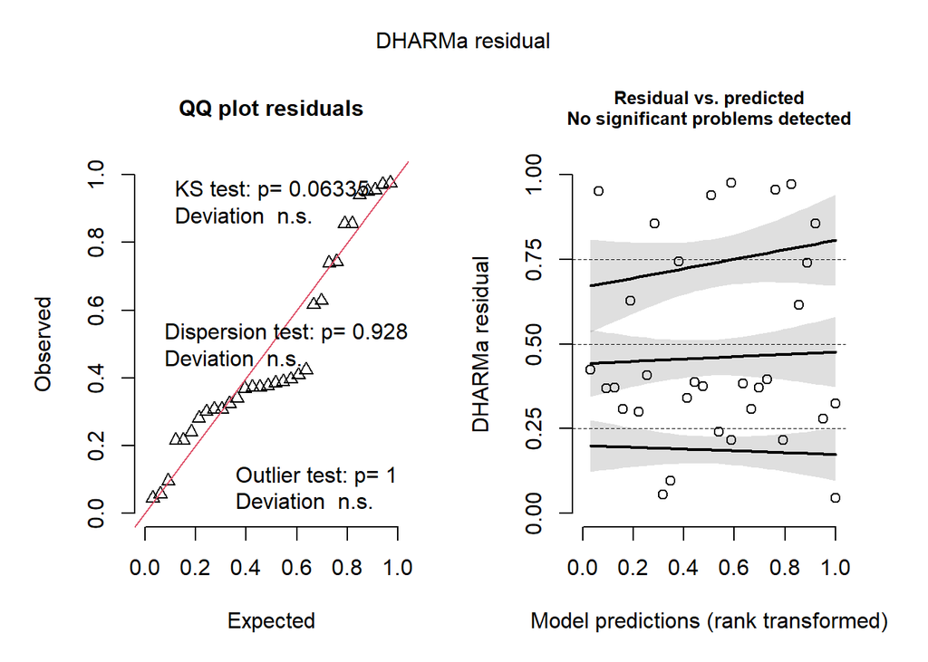

```r
simulationOutput <- simulateResiduals(fittedModel = lm_model, plot = FALSE)
plot(simulationOutput)
```

## Difference in species prediction between mature *F. sanguinea* ants and their slaves

```r
model_input <- dev_samples[dev_samples$species=="F. sanguinea"&dev_samples$callow==0,]
model_input$index_diff <- model_input$predicted_species - find_nestmates_SII(model_input$chromatogram_ID, dev_samples)
lm_model <- lmer(index_diff~sang_prop+(1|colony)+(1|colony:census_date), data=model_input)
```

```
## boundary (singular) fit: see help('isSingular')
```

```r
print(summary(lm_model))
```

```
## Linear mixed model fit by REML. t-tests use Satterthwaite's method ['lmerModLmerTest']
## Formula: index_diff ~ sang_prop + (1 | colony) + (1 | colony:census_date)
##    Data: model_input
##
## REML criterion at convergence: -23.7
##
## Scaled residuals:
##      Min       1Q   Median       3Q      Max
## -1.75772 -0.51123  0.02544  0.53816  1.40767
##
## Random effects:
##  Groups             Name        Variance Std.Dev.
##  colony:census_date (Intercept) 0.03106  0.1762
##  colony             (Intercept) 0.00000  0.0000
##  Residual                       0.01495  0.1223
## Number of obs: 63, groups:  colony:census_date, 40; colony, 16
##
## Fixed effects:
##             Estimate Std. Error       df t value Pr(>|t|)
## (Intercept)  0.17658    0.05717 35.83866   3.089  0.00387 **
## sang_prop   -0.08830    0.11633 34.28029  -0.759  0.45304
## ---
## Signif. codes:  0 '***' 0.001 '**' 0.01 '*' 0.05 '.' 0.1 ' ' 1
##
## Correlation of Fixed Effects:
##           (Intr)
## sang_prop -0.827
## optimizer (nloptwrap) convergence code: 0 (OK)
## boundary (singular) fit: see help('isSingular')
```

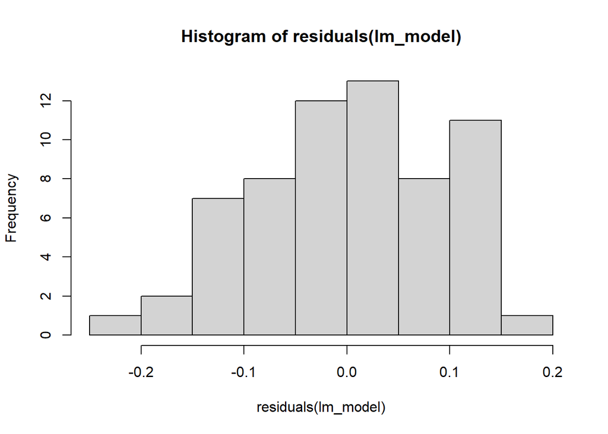

```r
# model diagnostics
hist(residuals(lm_model))
```

```r
print(shapiro.test(residuals(lm_model)))
```

```
##
##  Shapiro-Wilk normality test
##
## data:  residuals(lm_model)
## W = 0.98152, p-value = 0.4623
```

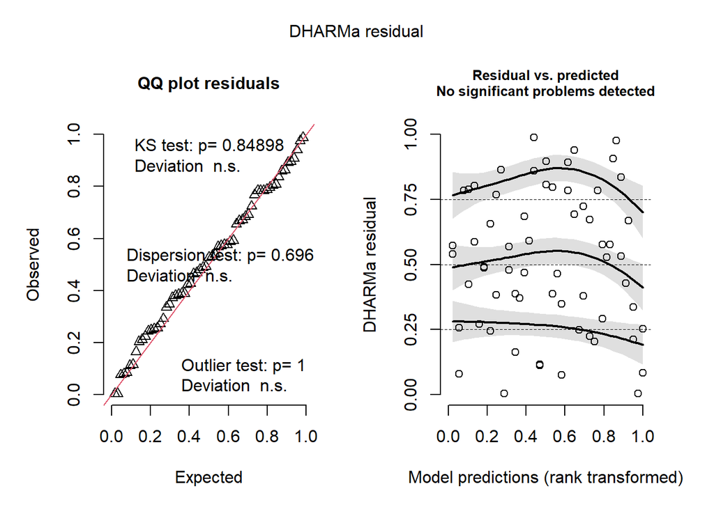

```r
simulationOutput <- simulateResiduals(fittedModel = lm_model, plot = FALSE)
plot(simulationOutput)
```

## Difference in species prediction between callow *F. sanguinea* ants and their slaves

Since the linear model does not meet one of diagnostics criterion we will apply Wilcoxon paired test.

```r
library(ggpubr)
library(rstatix)
model_input <- dev_samples[dev_samples$species=="F. sanguinea"&dev_samples$callow==1,]
model_input$slave_species_index <- find_nestmates_SII(model_input$chromatogram_ID, dev_samples)
print(wilcox.test(model_input$predicted_species, model_input$slave_species_index, paired=TRUE))
```

```
##
##  Wilcoxon signed rank exact test
##
## data:  model_input$predicted_species and model_input$slave_species_index
## V = 212, p-value = 0.685
## alternative hypothesis: true location shift is not equal to 0
```

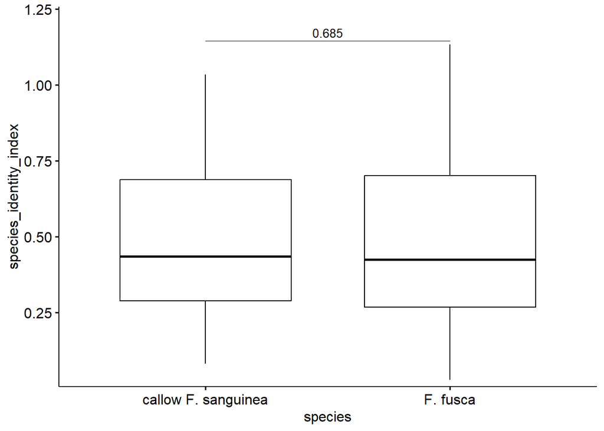

```r
df <- data.frame(species_identity_index=c(model_input$predicted_species, model_input$slave_species_index), species="F. fusca")
df$species[1:nrow(model_input)] <- "callow F. sanguinea"
stat_tests <- wilcox_test(df, species_identity_index~species, paired=TRUE) %>%
  add_significance("p") %>%
  add_xy_position(x="species", dodge=0.8, fun="max")
ggboxplot(df, x="species", y="species_identity_index")+
  scale_y_continuous(expand = expansion(mult=c(0.02,0.1)))+
  stat_pvalue_manual(stat_tests, label="p", tip.length = 0, size=3.5)
```

## Difference in species prediction between callow and mature *F. sanguinea* ants.

```r
model_input <- dev_samples[dev_samples$species=="F. sanguinea"&dev_samples$callow==1,]
model_input$index_diff <- model_input$predicted_species - find_nestmates_SII(model_input$chromatogram_ID, dev_samples, heterospecific = FALSE)
# no random effect since it captures no variance
lm_model <- lm(index_diff~sang_prop, data=model_input)
print(summary(lm_model))
```

```
##
## Call:
## lm(formula = index_diff ~ sang_prop, data = model_input)
##
## Residuals:
##      Min       1Q   Median       3Q      Max
## -0.23777 -0.09746 -0.03337  0.07834  0.29886
##
## Coefficients:
##             Estimate Std. Error t value Pr(>|t|)
## (Intercept) -0.20324    0.05102  -3.983 0.000439 ***
## sang_prop    0.10312    0.09334   1.105 0.278652
## ---
## Signif. codes:  0 '***' 0.001 '**' 0.01 '*' 0.05 '.' 0.1 ' ' 1
##
## Residual standard error: 0.1524 on 28 degrees of freedom
##   (2 obserwacje zostały skasowane z uwagi na braki w nich zawarte)
## Multiple R-squared:  0.04177,    Adjusted R-squared:  0.007549
## F-statistic: 1.221 on 1 and 28 DF,  p-value: 0.2787
```

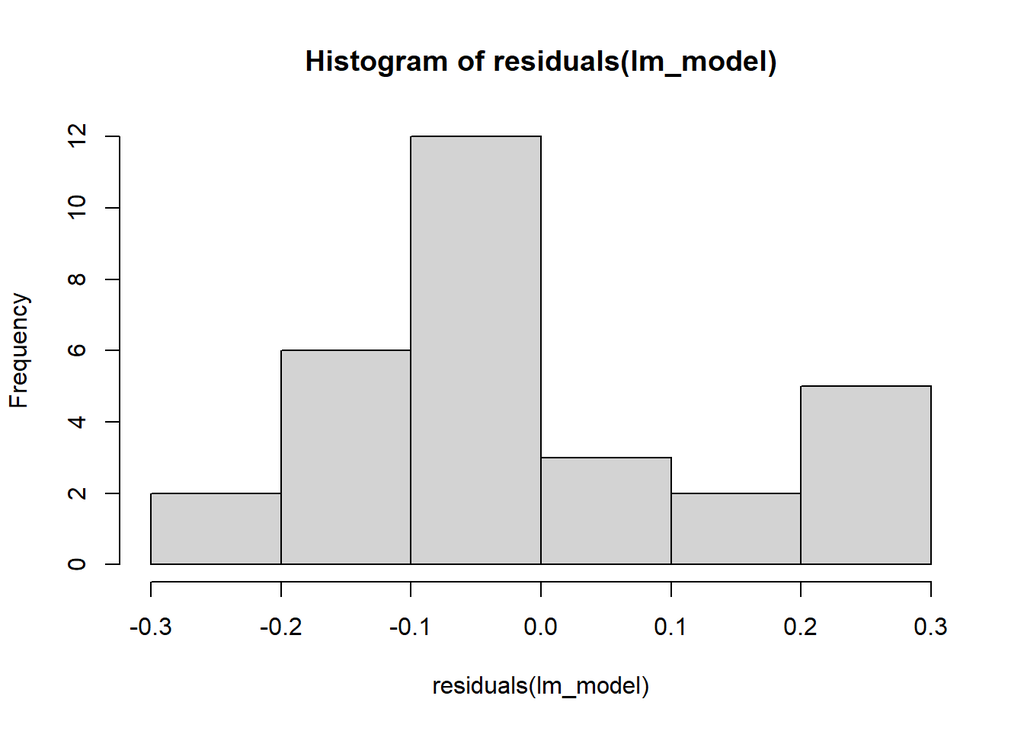

```r
# model diagnostics
hist(residuals(lm_model))
```

```r
print(shapiro.test(residuals(lm_model)))
```

```
##
##  Shapiro-Wilk normality test
##
## data:  residuals(lm_model)
## W = 0.91295, p-value = 0.01768
```